# Homework 4

Classification of liver malfunction severity (Random Forest)

Ian Effendi

November 07, 2021

## Certification

> I certify that I indeed finished reading Ch. 5 from *An Introduction to Statistical Learning*, by James Gareth, Daniela Witten, Trevor Hastie, Robert Tibshirani.

## Environment Setup

The usual steps are taken to setup our work environment. We start by importing the necessary libraries into the `R` namespace:

```r
# Import the packages necessary for this analysis.
library(MASS)
library(magrittr)
library(ggplot2)
library(dplyr)
library(readr)
library(here)
```

We can then follow up by importing our data. An external script, `data-raw/Liver.R` handles importing the original `Liver.txt`, converting it into a `tbl_df` with the appropriate column names and types, and saving some additional intermediate structures.

We load the following from the project `data/` directory:

- `Liver`: a `tbl_df` containing 6 features and 1 response column.
- `Liver.features`: a column subset of `Liver` containing only features.
- `Liver.truth`: a ground truth logical derived from `Liver$severity`. (`TRUE = "Severe"`)
- `Liver.labels`: a ground truth set of factors with class labels instead of logical values.

```r
# External script handles preprocessing Liver into a properly typed data.frame.
source(here("data-raw/Liver.R"))
```

```
Liver (features): tibble [345 x 6] (S3: tbl_df/tbl/data.frame)
 $ blood.1: num [1:345] 85 85 86 91 87 98 88 88 92 90 ...
 $ blood.2: num [1:345] 92 64 54 78 70 55 62 67 54 60 ...
 $ blood.3: num [1:345] 45 59 33 34 12 13 20 21 22 25 ...
 $ blood.4: num [1:345] 27 32 16 24 28 17 17 11 20 19 ...
 $ blood.5: num [1:345] 31 23 54 36 10 17 9 11 7 5 ...
 $ drinks : num [1:345] 0 0 0 0 0 0 0.5 0.5 0.5 0.5 ...
Liver (truth):  logi [1:345] TRUE FALSE FALSE FALSE FALSE FALSE ...
Liver (labels):  Factor w/ 2 levels "Not Severe","Severe": 2 1 1 1 1 1 2 2 2 2 ...
```

```r
# Read the data into memory.
Liver <- read_rds(here("data/Liver.rds"))
Liver.features <- read_rds(here("data/Liver.features.rds"))
Liver.truth <- read_rds(here("data/Liver.truth.rds"))
Liver.labels <- read_rds(here("data/Liver.labels.rds"))

# Save some additional variables for later reuse.
n_samples = nrow(Liver)
n_features = ncol(Liver.features)
```

## Overview

In this assignment we will be comparing cross-validation results from `LDA` and `RandomForest` models.

## 1. Box-Cox Transformation of Liver Features

### Box-Cox Transformation

We can produce a quantile plot to check the assumption of normal distribution for the predictors present in the Liver dataset, using the following function:

```r
#' Create quantile plot for a feature vector.
#' @param .vec Data containing the feature vector values.
#' @param ... Graphing parameters.
qqplot.feature <- function(.vec, ...) {
    qqnorm(.vec, ...)
    qqline(.vec, ...)
}

#' Create quantile plot of the data.frame for the specified predictors.
#'
#' @param .data data.frame containing predictors.
#' @param ... Graphing parameters.
#' @param cols Predictors to select from the original dataset.
qqplot.data <- function(.data, ..., cols = 1:6) {
    labels = colnames(.data)
    fig.x <- max(as.integer(max(cols) / 2), 2)
    fig.y <- 2
    cols <- if(is.null(cols)) 1:ncol(.data) else cols
    par(mfrow=c(fig.x, fig.y))
    for(i in cols){
        main = paste0(c("Normal Q-Q Plot", labels[i]))
        qqplot.feature(.data %>% pull(i), main = main, ...)
    }
}
```

As shown below, `blood.1` is the only predictor that appears to already have a normal distribution. The remaining predictors to not fit the assumption of normality, and that can have an impact on the performance of our model.

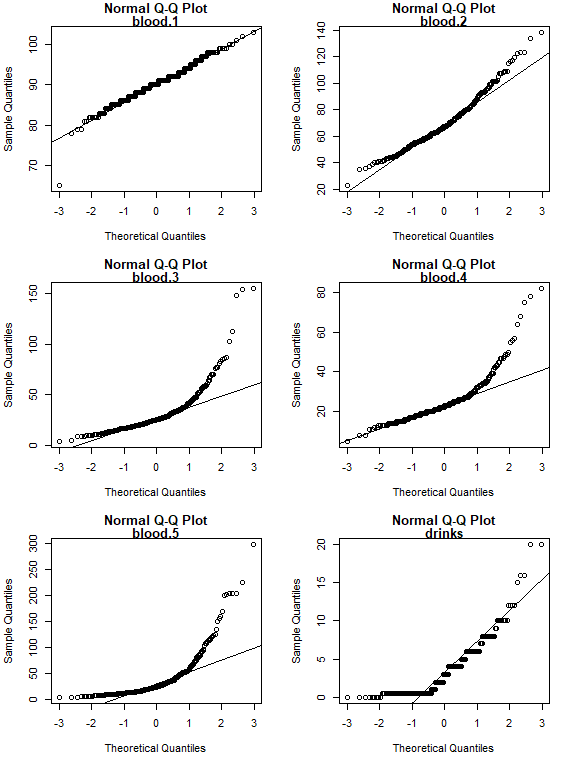

```r
# Plot the normal distributions for all features present in `Liver`.
Liver %>% qqplot.data()
```

Not every predictor appears to adhere to a normal distribution, so performing a Box-Cox transformation should improve this. We can perform the transformation with the following function:

```r
#' Perform a box-cox transformation.
#' @param .features data.frame containing predictor variables.
#' @param .response single-column data.frame containing response labels.
boxcox.transform <- function(.features, .response) {
    p <- ncol(.features)
    features.transformed <- .features
    Powers <- rep(NA, p)
    for(i in 1:p) {
        power.fit <- MASS::boxcox(.features[[i]] + 1 ~ .response, plotit = FALSE)
        power.ind <- match(max(power.fit$y), power.fit$y)
        Power.i <- power.fit$x[power.ind]
        Powers[i] <- Power.i
        if(Power.i == 0) {
            features.transformed[[i]] <- log(.features[[i]] + 1)
        } else {
            features.transformed[[i]] <- ((.features[[i]] + 1)^Power.i)
        }
    }
    return(list(
        Powers = Powers,
        features = features.transformed
    ))
}
```

Shown below are the results of the transformation on the features. The transformed features appear to be normally distributed, with the exception of `drinks`, which appears to have very influential leverage points:

```r
# Perform the Box-Cox Transformation.
transformation <- boxcox.transform(Liver.features, Liver.labels)

# Display the calculated powers.
cat("Box-Cox Transformation Powers: ", transformation$Powers, "\n")
```

```
Box-Cox Transformation Powers:  2 0.1 -0.2 -0.2 -0.3 -0.1
```

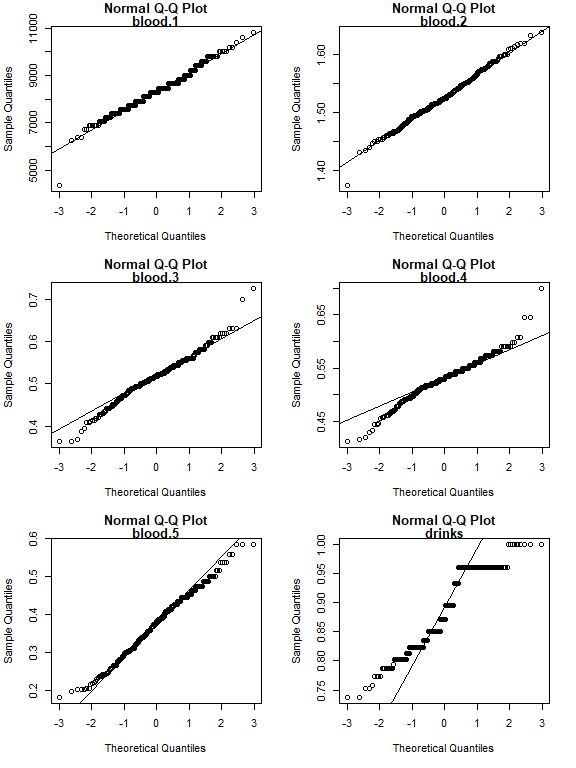

```r
# Display the transformed features.
transformation$features %>% qqplot.data()
```

## 2. Cross-Validation of Linear Discriminant Analysis (LDA)

We can take our transformed data and preprae a `data.frame` for use in our cross-validation processes:

```r
# Create data.frame from transformation features.
Liver.boxcox.df <- bind_cols(transformation$features, Y = Liver.truth)
Liver.boxcox.df
```

[output not shown]

The following functions will perform $k$-fold cross-validation using the `lda` model provided by the `MASS` package.

```r
#' Calculate accuracy.
#' @param mat 2 by 2 matrix containing confusion matrix values.
calc.accuracy <- function(mat) {
    return(sum(diag(mat)) / sum(mat))
}

#' Calculate misclassification error.
#' @param mat 2 by 2 matrix containing confusion matrix values.
calc.error <- function(mat) {
    return(1 - calc.accuracy(mat))
}

#' Calculate the confidence interval
#' @param avg Average value.
#' @param stderr Standard error of value.
calc.confint <- function(avg, stderr) {
    return(list(
        lower = avg - stderr,
        upper = avg + stderr
    ))
}

#' Perform k-fold LDA Cross-Validation
#' @param .data data.frame with features and response in column "Y".
#' @param .truth vector containing ground truth/labels.
#' @param ... Additional params.
#' @param k Number of folds.
#' @param m Number of rounds.
lda.CV.error <- function(.data, .truth, ..., k=3, m=100) {
    # Prepare the cross-validation results matrix.
    Cost <- matrix(0, m)
    # Perform `m` rounds of cross-validation.
    for (i in 1:m) {
        # Sub-sample `k` folds.
        fold = sample(rep(1:k, length = nrow(.data)))
        for (j in 1:k) {
            # Condition for selecting the `j`th fold.
            subset.j <- (fold == j)

            # Split into train and test data.
            train.j <- .data %>% subset(!subset.j)
            test.j <- .data %>% subset(subset.j)
            truth.j <- .truth %>% subset(subset.j)

            # Fit model.
            model.j <- MASS::lda(Y ~ ., data = train.j)
            preds.j <- predict(model.j, newdata = test.j)$class

            # Calculate the number misclassified:
            falseneg.j <- sum((preds.j == FALSE) & (truth.j == TRUE))
            falsepos.j <- sum((preds.j == TRUE) & (truth.j == FALSE))
            misclassified.j <- falseneg.j + falsepos.j

            # Add total misclassified to round `i` total.
            # and add the error rate.
            Cost[i] <- Cost[i] + misclassified.j
        }
    }

    # Calculate the average number of misclassified cases.
    avg.Cost <- mean(Cost)

    # Calculate the standard error of misclassified cases.
    stderr.Cost <- sd(Cost)/sqrt(length(Cost))

    # Calculate the confidence interval of misclassified cases.
    confint.Cost <- calc.confint(avg.Cost, stderr.Cost)

    # Calculate the average error rate.
    avg.Error <- mean(Cost/nrow(.data))

    # Calculate the standard error of the average error rate.
    stderr.Error <- sd(Cost/nrow(.data))/sqrt(length(Cost))

    # Calculate the confidence interval for the error.
    confint.Error <- calc.confint(avg.Error, stderr.Error)

    # Return calculated values.
    return(list(
        k = k,
        m = m,
        Cost = Cost,
        avg.Cost = avg.Cost,
        stderr.Cost = stderr.Cost,
        confint.Cost = confint.Cost,
        avg.Error = avg.Error,
        stderr.Error = stderr.Error,
        confint.Error = confint.Error
    ))
}
```

We can display the results from our cross-validation fits using the following functions:

```r
# Prepare formatters.
int.format <- function(x) sprintf("%i", as.integer(x))
float.format <- function(x) sprintf("%f", x)
stderr.format <- function(x) sprintf("%.5f", x)
rate.format <- function(x) sprintf("%.2f%%", x * 100)
confint.format <- function(avg, stderr, lower, upper) sprintf("(%s +/- %s) = [%s, %s]", avg, stderr, lower, upper)
label.CV.format <- function(k, m) sprintf("%s-fold CV (%s Rounds)", int.format(k), int.format(m))

#' Summarize the results.
#' @param results Results of call to `lda.CV.error()`.
lda.CV.summary <- function(results) {
    # Get the label.
    label <- label.CV.format(results$k, results$m)
    cat(sprintf("[%s] Average misclassified cases = %.2f", label, results$avg.Cost), "\n")
    cat(sprintf("[%s] Standard error of total misclassified cases = +/- %s", label, stderr.format(results$stderr.Cost)), "\n")
    cat(sprintf("[%s] 95%% Confidence Interval for misclassified cases = %s", label, confint.format(float.format(results$avg.Cost), stderr.format(results$stderr.Cost), float.format(results$confint.Cost$lower), float.format(results$confint.Cost$upper))), "\n")

    cat(sprintf("[%s] Average error rate = %s", label, rate.format(results$avg.Error)), "\n")
    cat(sprintf("[%s] Standard error of total error rate = +/- %s", label, rate.format(results$stderr.Error)), "\n")
    cat(sprintf("[%s] 95%% Confidence Interval for error rate = %s", label, confint.format(rate.format(results$avg.Error), rate.format(results$stderr.Error), rate.format(results$confint.Error$lower), rate.format(results$confint.Error$upper))), "\n")
}
```

### $3$-fold CV, 100 Rounds

```r
# Perform 3-fold, 100 Round CV.
k3.m100.cv <- lda.CV.error(Liver.boxcox.df, Liver.truth, k = 3, m = 100)
# str(k3.m100.cv)
lda.CV.summary(k3.m100.cv)
```

```
[3-fold CV (100 Rounds)] Average misclassified cases = 93.01
[3-fold CV (100 Rounds)] Standard error of total misclassified cases = +/- 0.41304
[3-fold CV (100 Rounds)] 95% Confidence Interval for misclassified cases = (93.010000 +/- 0.41304) = [92.596956, 93.423044]
[3-fold CV (100 Rounds)] Average error rate = 26.96%
[3-fold CV (100 Rounds)] Standard error of total error rate = +/- 0.12%
[3-fold CV (100 Rounds)] 95% Confidence Interval for error rate = (26.96% +/- 0.12%) = [26.84%, 27.08%]
```

### $10$-fold CV, 100 Rounds

```r
# Perform 10-fold, 100-Round CV.
k10.m100.cv <- lda.CV.error(Liver.boxcox.df, Liver.truth, k = 10, m = 100)
# str(k10.m100.cv)
lda.CV.summary(k10.m100.cv)
```

```
[10-fold CV (100 Rounds)] Average misclassified cases = 92.58
[10-fold CV (100 Rounds)] Standard error of total misclassified cases = +/- 0.24254
[10-fold CV (100 Rounds)] 95% Confidence Interval for misclassified cases = (92.580000 +/- 0.24254) = [92.337463, 92.822537]
[10-fold CV (100 Rounds)] Average error rate = 26.83%
[10-fold CV (100 Rounds)] Standard error of total error rate = +/- 0.07%
[10-fold CV (100 Rounds)] 95% Confidence Interval for error rate = (26.83% +/- 0.07%) = [26.76%, 26.91%]
```

### Whole Learning Sample Model

The lecture material used the transformed whole learning sample to fit an LDA model. Fitting that model on the whole learning sample produces the following results:

```r
review.lda <- new.env(parent = emptyenv())
review.lda$X <- transformation$features
review.lda$Y <- Liver.truth
review.lda$FitObj <- lda(review.lda$X, review.lda$Y)
review.lda$PredObj <- predict(review.lda$FitObj, review.lda$X)
review.lda$Table <- table(review.lda$PredObj$class, review.lda$Y)
review.lda$FitObj
```

```
Call:
lda(review.lda$X, review.lda$Y)

Prior probabilities of groups:
    FALSE      TRUE
0.5797101 0.4202899

Group means:
       blood.1  blood.2   blood.3   blood.4  blood.5    drinks
FALSE 8270.335 1.523529 0.5225142 0.5252822 0.359250 0.8843464
TRUE  8411.745 1.531254 0.5107952 0.5370008 0.396069 0.8901261

Coefficients of linear discriminants:
                  LD1
blood.1  4.334768e-04
blood.2  8.431653e+00
blood.3 -2.411588e+01
blood.4  2.231672e+01
blood.5  1.207913e+01
drinks  -1.863786e+00
```

```r
review.lda$Table
```

```
        FALSE TRUE
  FALSE   169   56
  TRUE     31   89
```

```r
cat(sprintf("Error rate from lecture: %.5f%%", calc.error(review.lda$Table) * 100), "\n")
```

```
Error rate from lecture: 25.21739%
```

The lecture’s model has an error rate of $\approx 25.22$%. The lecture’s error rate is the *training* error rate, whereas our $k$-fold CV is the *validation* error rate.

So why the slight increase in error rate (and consequently, a decrease in model accuracy)? It’s more likely that $k$-fold CV is giving a better approximation for the model’s accuracy on this dataset, as it is less prone to overfitting.

## 4. Cross-Validation of Random Forest Classifier

```r
# Import the randomForest function.
library(randomForest)
# Create data.frame from transformation features.
Liver.df <- bind_cols(Liver.features, Y = Liver.labels)
Liver.df
```

| blood.1 | blood.2 | blood.3 | blood.4 | blood.5 | drinks | Y |
| --- | --- | --- | --- | --- | --- | --- |
| 85 | 92 | 45 | 27 | 31 | 0.0 | Severe |
| 85 | 64 | 59 | 32 | 23 | 0.0 | Not Severe |
| 86 | 54 | 33 | 16 | 54 | 0.0 | Not Severe |
| 91 | 78 | 34 | 24 | 36 | 0.0 | Not Severe |
| 87 | 70 | 12 | 28 | 10 | 0.0 | Not Severe |
| 98 | 55 | 13 | 17 | 17 | 0.0 | Not Severe |
| 88 | 62 | 20 | 17 | 9 | 0.5 | Severe |
| 88 | 67 | 21 | 11 | 11 | 0.5 | Severe |
| 92 | 54 | 22 | 20 | 7 | 0.5 | Severe |
| 90 | 60 | 25 | 19 | 5 | 0.5 | Severe |

[output cut: 335 more lines]

We will explore optimality and sensitivity to:

```r
#' Calculate table accuracy.
calc.table.accuracy <- function(arr) {
    return(calc.accuracy(arr[,1:2]))
}

#' Calculate table error.
calc.table.error <- function(arr) {
    return(calc.error(arr[,1:2]))
}

#' Perform k-fold Random Forest Cross-Validation
#' @param .data data.frame with features and response in column "Y".
#' @param .truth vector containing ground truth/labels.
#' @param ... Additional params.
#' @param k Number of folds.
#' @param m Number of seeds. Equivalent to number of rounds.
#' @param mtry Number of variables randomly sampled as candidates for each split.
#' @param nodesize Minimum size of the terminal nodes.
#' @param ntrees Number of trees.
rf.CV.error <- function(.data, .truth, ..., k=3, m=10, mtry=c(2:5), nodesize=c(1:10), ntree=500, init.seed=99) {
    # Get the iterator sizes.
    P <- length(mtry)
    S <- length(nodesize)

    # Create an array that will store results for the models fit.
    # m matrices of size r x c.
    # Dimensions: [r,c,m,P,S]
    # - r: Row index.
    # - c: Column index.
    # - m: Round index.
    # - P: mtrys option index.
    # - S: nodesizes option index.
    Table.arr <- array(0, c(2,3,m,P,S))

    # Array is m matrices with 2 rows and 3 columns each.
    n_samples <- nrow(.data)
    n_features <- ncol(.data)

    # Perform m "Rounds", each with a different seed.
    for(i in 1:m) {

        # Set the random seed for the Random Forest.
        seed.i <- as.integer(init.seed + i)
        set.seed(seed.i)

        # Perform a fit for each `mtry` option.
        for(p in 1:P) {

            # Perform a fit for each `nodesize` option.
            for(s in 1:S) {

                # Fold confusion array.
                Fold.arr <- array(0, c(2,3,k))

                # Sub-sample `k` folds.
                fold = sample(rep(1:k, length = n_samples))
                for (j in 1:k) {

                    # Condition for selecting the `j`th fold.
                    subset.j <- (fold == j)

                    # Split into train and test data.
                    train.j <- .data %>% subset(!subset.j)
                    test.j <- .data %>% subset(subset.j)
                    truth.j <- .truth %>% subset(subset.j)

                    # Subset features and response.
                    X.train.j <- train.j %>% dplyr::select(-Y)
                    Y.train.j <- train.j %>% dplyr::pull(Y)
                    X.test.j <- test.j %>% dplyr::select(-Y)
                    Y.test.j <- truth.j

                    # Fit model.
                    fit.j <- randomForest(X.train.j, Y.train.j, mtry=mtry[p], nodesize=nodesize[s], ntree=ntree)
                    pred.j <- predict(fit.j, newdata = X.test.j)

                    # Calculate the error rate for this particular model.
                    table.j <- table(pred.j, truth.j)
                    poserror.j <- table.j[1,2] / sum(table.j[1,])
                    negerror.j <- table.j[2,1] / sum(table.j[2,])
                    confusion.j <- cbind(table.j, c(poserror.j, negerror.j))

                    # Add fold's confusion results.
                    Fold.arr[,,j] <- Fold.arr[,,j] + confusion.j
                }

                # Average folds to get Round confusion matrix.
                Table.arr[,,i,p,s] <- apply(Fold.arr, 1:2, mean)

            }
        }
    }

    # Calculate the error rate for each 'Round'
    Error.arr <- apply(Table.arr, c(3:5), calc.table.error)

    # Calculate the standard deviation of error rate per 'Round'.
    sd.Error <- apply(Error.arr, 2:3, sd)

    # Calculate the mean error rate per 'Round'.
    avg.Error <- apply(Error.arr, 2:3, mean)

    # Calculate the standard error.
    stderr.Error <- sd.Error/sqrt(m)

    # Return metrics.
    return(list(
        Table.arr = Table.arr,
        Error.arr = Error.arr,
        sd.Error = sd.Error,
        avg.Error = avg.Error,
        stderr.Error = stderr.Error
    ))
}
```

We can display the results from our cross-validation fits using the following functions:

```r
#' Summarize the results.
#' @param results Results of call to `rf.CV.error()`.
rf.CV.summary <- function(results) {
    str(results)
    label = sprintf("Random Forest (%i-fold CV, %i trees)", results$k, results$ntree)
    par(mar=c(6, 5, 5, 2)+0.1)
    matplot(t(100 * results$avg.Error), type="l", xlab = "Node size", ylab = "Mean error of classification [%]", main = "A")
    matplot(t(100 * results$sd.Error), type="l", xlab = "Node size", ylab = "St.dev of error of classification [%]", main = "B")
    matplot(t(100 * results$stderr.Error), type="l", xlab = "Node size", ylab = "St.Error of mean classification error [%]", main = "C")
}
```

```r
rf.cv1 <- new.env(parent = emptyenv())
rf.cv1$filename <- here("data/rf.k10.t500.rds")
if(file.exists(rf.cv1$filename)) {
    message("File exists. Loading from cache...")
    load(file=rf.cv1$filename)
} else {
    # Fit model and save to cache.
    k10.t500 <- rf.CV.error(Liver.df, Liver.truth, k=5, m=10, mtry=c(2:5), nodesize=c(1:5), ntree=10, init.seed=1)
    save(k10.t500, file=rf.cv1$filename)
}
```

```
File exists. Loading from cache...
```

```
List of 5
 $ Table.arr   : num [1:2, 1:3, 1:10, 1:4, 1:5] 31.4 8.6 12.8 16.2 0.285 ...
 $ Error.arr   : num [1:10, 1:4, 1:5] 0.31 0.31 0.328 0.325 0.301 ...
 $ sd.Error    : num [1:4, 1:5] 0.0152 0.0304 0.0122 0.0107 0.0164 ...
 $ avg.Error   : num [1:4, 1:5] 0.305 0.317 0.314 0.303 0.322 ...
 $ stderr.Error: num [1:4, 1:5] 0.00481 0.00962 0.00387 0.00338 0.00518 ...
```

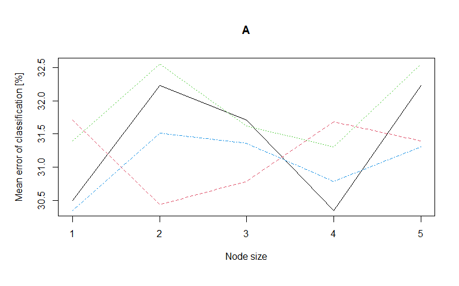

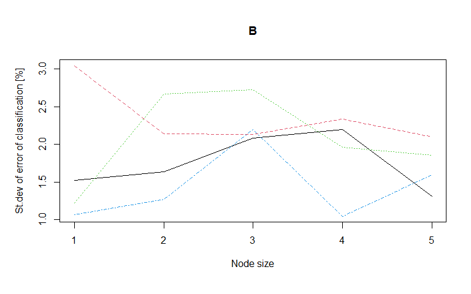

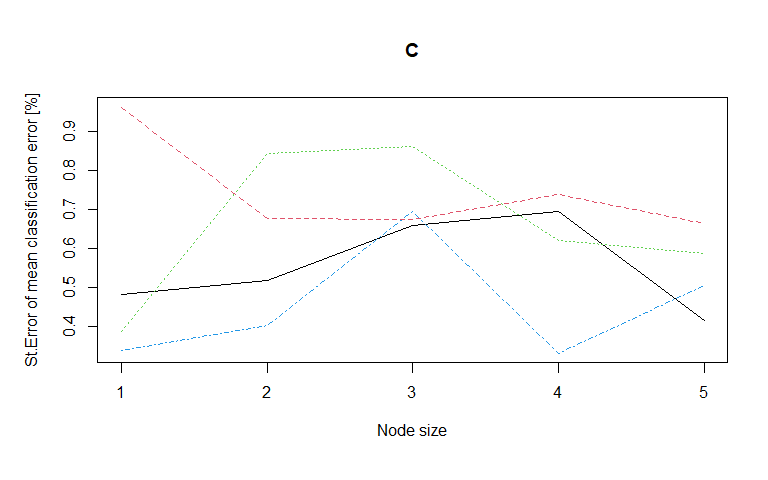

```r
rf.CV.summary(k10.t500)
```

```r
k10.t500.forest.cv$Error.arr
```

```
, , 1

           [,1]      [,2]      [,3]      [,4]
 [1,] 0.3101449 0.3130435 0.3275362 0.3043478
 [2,] 0.3101449 0.3159420 0.3072464 0.3043478
 [3,] 0.3275362 0.3449275 0.3014493 0.2985507
 [4,] 0.3246377 0.2608696 0.3217391 0.2869565
 [5,] 0.3014493 0.2869565 0.3275362 0.2898551
 [6,] 0.3101449 0.3101449 0.3217391 0.3072464
 [7,] 0.2956522 0.2985507 0.3188406 0.2985507
 [8,] 0.2985507 0.3304348 0.3159420 0.3217391
 [9,] 0.2753623 0.3565217 0.2898551 0.3159420
[10,] 0.2956522 0.3536232 0.3072464 0.3072464

, , 2
```

[output cut: 54 more lines]

```r
# Perform 10-fold, 10 seed CV on 1000 trees.
k10.t1000.forest.cv <- rf.CV.error(Liver.df, Liver.truth, k = 10, m = 100)
# str(k10.m100.cv)
# rf.CV.summary(k10.m100.cv)
```

### Whole Learning Sample Model

The lecture material used the whole learning sample to fit a Random Forest classifier. Fitting that model on the whole learning sample produces the following results:

```r
set.seed(100)
review.rf <- new.env(parent = emptyenv())
review.rf$X <- Liver.features # Predictors.
review.rf$Y <- Liver.labels # Already a factor.
review.rf$FitObj <- randomForest(Liver.features, review.rf$Y)
review.rf$FitObj
```

```
Call:
 randomForest(x = Liver.features, y = review.rf$Y)
               Type of random forest: classification
                     Number of trees: 500
No. of variables tried at each split: 2

        OOB estimate of  error rate: 26.67%
Confusion matrix:
           Not Severe Severe class.error
Not Severe        168     32   0.1600000
Severe             60     85   0.4137931
```

```r
review.rf$Table <- review.rf$FitObj$confusion[,1:2]
review.rf$Table
```

```
           Not Severe Severe
Not Severe        168     32
Severe             60     85
```

```r
cat(sprintf("Error rate from lecture: %.5f%%", calc.error(review.rf$Table) * 100), "\n")
```

```
Error rate from lecture: 26.66667%
```

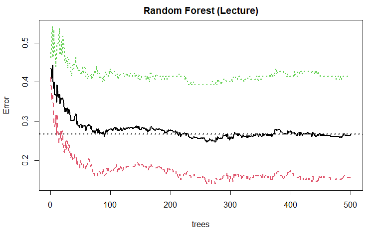

```r
plot(review.rf$FitObj, lwd=2, main = "Random Forest (Lecture)")
abline(h=0.2667, lty=3, lwd=2)
```